# Prediction Assignment Writeup

Ramesh Thyagarajan

January 27, 2016

## Human Activity Recognition

The goal of your project is to predict the manner in which they did the exercise. This is the “classe” variable in the training set. You may use any of the other variables to predict with. You should create a report describing how you built your model, how you used cross validation, what you think the expected out of sample error is, and why you made the choices you did. You will also use your prediction model to predict 20 different test cases.

```r
library(knitr)
library(caret)
```

```r
library(rpart)
library(rpart.plot)
library(randomForest)
library(RColorBrewer)
library(rattle)
```

Reproducibility - Set seed

```r
set.seed(55555)
```

Data retrieval and exploration

```r
trainUrl <- "http://d396qusza40orc.cloudfront.net/predmachlearn/pml-training.csv"
testUrl <- "http://d396qusza40orc.cloudfront.net/predmachlearn/pml-testing.csv"

# trainfile<-"./Data/pml-training.csv"
# testfile<-"./Data/pml-testing.csv"

#download.file(trainUrl,trainfile,method="curl")
#download.file(trainUrl,testfile,method="curl")


training <- read.csv(url(trainUrl), na.strings=c("NA","#DIV/0!",""))
testing <- read.csv(url(testUrl), na.strings=c("NA","#DIV/0!",""))
```

Data partioning into training(60%) & testing (40%)

```r
inTrain <- createDataPartition(training$classe, p=0.6, list=FALSE)
myTraining <- training[inTrain, ]
myTesting <- training[-inTrain, ]
dim(myTraining)
```

```
## [1] 11776   160
```

```r
dim(myTesting)
```

```
## [1] 7846  160
```

### Data clensing

Removing near zero variance variables

```r
nzv <- nearZeroVar(myTraining, saveMetrics=TRUE)
myTraining <- myTraining[,nzv$nzv==FALSE]

nzv<- nearZeroVar(myTesting,saveMetrics=TRUE)
myTesting <- myTesting[,nzv$nzv==FALSE]
```

Removing the first column as its a running serial number

```r
myTraining<-myTraining[c(-1)]
```

```r
trg <- myTraining
for(i in 1:length(myTraining)) {
    if( sum( is.na( myTraining[, i] ) ) /nrow(myTraining) >= .7) {
        for(j in 1:length(trg)) {
            if( length( grep(names(myTraining[i]), names(trg)[j]) ) == 1)  {
                trg <- trg[ , -j]
            }
        }
    }
}

myTraining <- trg
```

Trasforming data sets

```r
clean1 <- colnames(myTraining)
clean2 <- colnames(myTraining[, -58])  # remove the classe column
myTesting <- myTesting[clean1]         # allow only variables in myTesting that are also in myTraining
testing <- testing[clean2]             # allow only variables in testing that are also in myTraining

dim(myTesting)
```

```
## [1] 7846   58
```

```r
dim(testing)
```

```
## [1] 20 57
```

Coercing the data into same type

```r
 for (i in 1:length(testing) ) {
     for(j in 1:length(myTraining)) {
         if( length( grep(names(myTraining[i]), names(testing)[j]) ) == 1)  {
             class(testing[j]) <- class(myTraining[i])
         }
     }
 }

# Get the same class between testing and myTraining
testing <- rbind(myTraining[2, -58] , testing)
testing <- testing[-1,]
```

## Prediction with Decision Trees

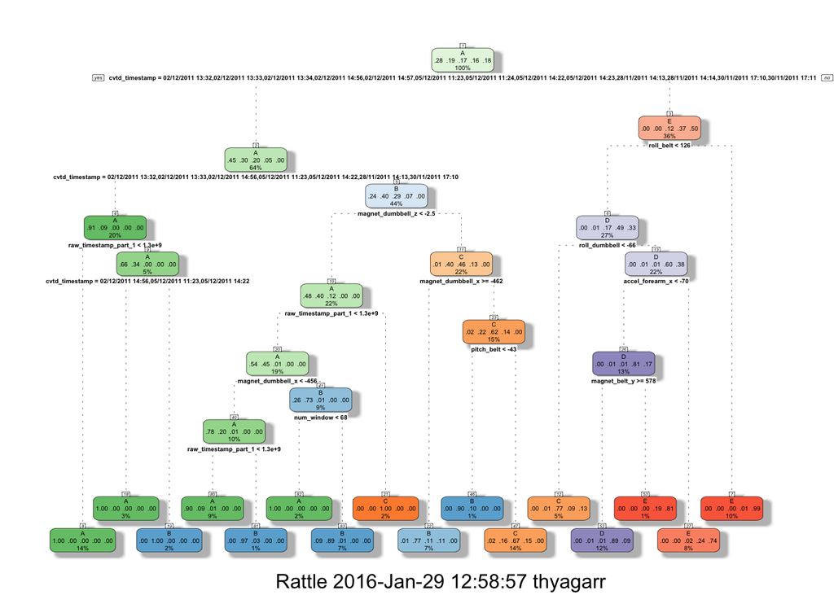

```r
modelFitDT <- rpart(classe ~., data=myTraining, method = "class")
fancyRpartPlot(modelFitDT)
```

```r
predictDT <- predict(modelFitDT, myTesting, type="class")
cmDT<- confusionMatrix(predictDT,myTesting$classe)
cmDT
```

```
## Confusion Matrix and Statistics
##
##           Reference
## Prediction    A    B    C    D    E
##          A 2161   74    8    4    0
##          B   45 1256   86   57    0
##          C   26  180 1254  192   57
##          D    0    8   12  830   98
##          E    0    0    8  203 1287
##
## Overall Statistics
##
##                Accuracy : 0.8652
##                  95% CI : (0.8574, 0.8726)
##     No Information Rate : 0.2845
##     P-Value [Acc > NIR] : < 2.2e-16
##
##                   Kappa : 0.8293
##  Mcnemar's Test P-Value : NA
##
## Statistics by Class:
##
##                      Class: A Class: B Class: C Class: D Class: E
## Sensitivity            0.9682   0.8274   0.9167   0.6454   0.8925
## Specificity            0.9847   0.9703   0.9298   0.9820   0.9671
## Pos Pred Value         0.9617   0.8698   0.7338   0.8755   0.8591
## Neg Pred Value         0.9873   0.9591   0.9814   0.9339   0.9756
## Prevalence             0.2845   0.1935   0.1744   0.1639   0.1838
## Detection Rate         0.2754   0.1601   0.1598   0.1058   0.1640
## Detection Prevalence   0.2864   0.1840   0.2178   0.1208   0.1909
## Balanced Accuracy      0.9764   0.8988   0.9232   0.8137   0.9298
```

## Prediction with Random Forest

```r
modelFitRF <- randomForest(classe ~., data=myTraining)
predictRF <- predict(modelFitRF, myTesting, type="class")
cmRF <- confusionMatrix(predictRF, myTesting$classe)
cmRF
```

```
## Confusion Matrix and Statistics
##
##           Reference
## Prediction    A    B    C    D    E
##          A 2232    4    0    0    0
##          B    0 1514    3    0    0
##          C    0    0 1365    0    0
##          D    0    0    0 1285    1
##          E    0    0    0    1 1441
##
## Overall Statistics
##
##                Accuracy : 0.9989
##                  95% CI : (0.9978, 0.9995)
##     No Information Rate : 0.2845
##     P-Value [Acc > NIR] : < 2.2e-16
##
##                   Kappa : 0.9985
##  Mcnemar's Test P-Value : NA
##
## Statistics by Class:
##
##                      Class: A Class: B Class: C Class: D Class: E
## Sensitivity            1.0000   0.9974   0.9978   0.9992   0.9993
## Specificity            0.9993   0.9995   1.0000   0.9998   0.9998
## Pos Pred Value         0.9982   0.9980   1.0000   0.9992   0.9993
## Neg Pred Value         1.0000   0.9994   0.9995   0.9998   0.9998
## Prevalence             0.2845   0.1935   0.1744   0.1639   0.1838
## Detection Rate         0.2845   0.1930   0.1740   0.1638   0.1837
## Detection Prevalence   0.2850   0.1933   0.1740   0.1639   0.1838
## Balanced Accuracy      0.9996   0.9984   0.9989   0.9995   0.9996
```

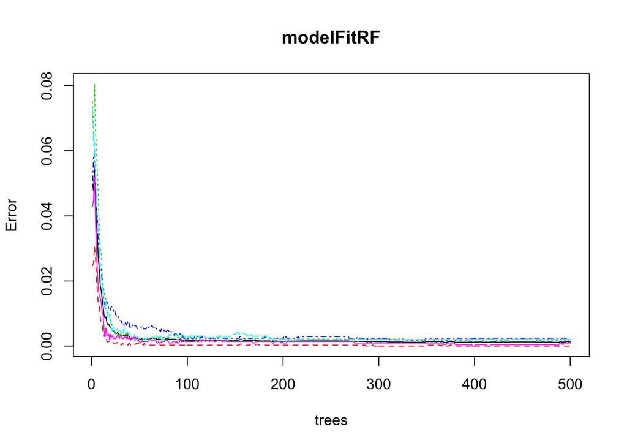

```r
plot(modelFitRF)
```

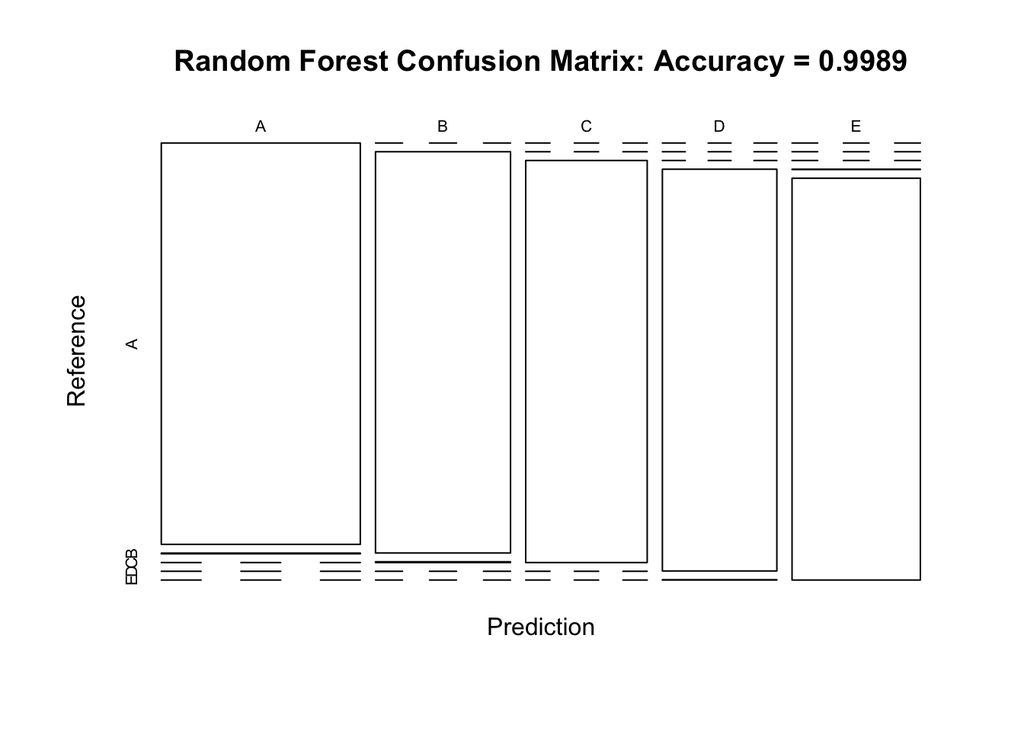

```r
plot(cmRF$table, col = cmDT$byClass, main = paste("Random Forest Confusion Matrix: Accuracy =", round(cmRF$overall['Accuracy'], 4)))
```

Random Forest model gave an accuray of 99.89% on test dataset, which more than the Decision Tree. The expected out-of-sample error is 100 - 99.89 = 0.11%

[output not shown]

```r
 Write_files = function(x){
     n=length(x)
     for (i in 1:n){
       filename = paste0("problem_id_", i,".txt")
       write.table(x[i], file = filename, quote = FALSE, row.names = FALSE, col.names = FALSE)
     }

 }
# #Write_files(predictRF_on_Test)
```

### Source of Data

Ugulino, W.; Cardador, D.; Vega, K.; Velloso, E.; Milidiu, R.; Fuks, H. Wearable Computing: Accelerometers’ Data Classification of Body Postures and Movements. Proceedings of 21st Brazilian Symposium on Artificial Intelligence. Advances in Artificial Intelligence - SBIA 2012. In: Lecture Notes in Computer Science. , pp. 52-61. Curitiba, PR: Springer Berlin / Heidelberg, 2012. ISBN 978-3-642-34458-9. DOI: 10.1007/978-3-642-34459-6_6.